# Práctica I

Análisis de componentes principales

Alejandro Lema Fernández (DNI 11864880-P) (Universidad Complutense de Madrid)  
2023-01-10

# Instrucciones (leer antes de empezar)

- Modifica dentro del documento `.Rmd` tus datos personales (nombre y DNI) ubicados en la cabecera del archivo.
- Asegúrate antes de seguir editando el documento que el archivo `.Rmd` compila (Knit) correctamente y se genera el `html` correspondiente.
- Los chunks creados están o vacíos o incompletos, de ahí que tengan la opción `eval = FALSE`. Una vez que edites lo que consideres debes de cambiar a `eval = TRUE` para que los chunk se ejecuten

## Paquetes necesarios

Necesitaremos los siguientes paquetes:

```r
# Borramos variables del environment
rm(list = ls())
library(readxl)
library(skimr)
library(corrr)
library(corrplot)
library(ggforce)
library(ggthemes)
library(tidyverse)
library(tidymodels)
library(factoextra)
library(FactoMineR)
library(ggplot2)
```

# Carga de datos

El archivo de datos a usar será `distritos.xlsx`

```r
distritos <- read_xlsx(path = "./distritos.xlsx")
```

El fichero contiene **información socioeconómica de los distritos de Madrid**

```r
glimpse(distritos)
```

```
Rows: 21
Columns: 25
$ Distrito        <chr> "CENTRO", "ARGANZUELA", "RETIRO", "SALAMANCA…
$ Superficie      <dbl> 522.82, 646.22, 546.62, 539.24, 917.55, 537.…
$ Densidad        <dbl> 268.68, 240.88, 220.27, 274.19, 160.81, 300.…
$ Pob_0_14        <dbl> 0.07040617, 0.11254129, 0.11331576, 0.103008…
$ Pob_15_29       <dbl> 0.1737976, 0.1490916, 0.1412689, 0.1682110, …
$ Pob_30_44       <dbl> 0.3158491, 0.2427674, 0.2042706, 0.2215154, …
$ Pob_45_64       <dbl> 0.2838425, 0.2963830, 0.2780623, 0.2682267, …
$ `Pob_65+`       <dbl> 0.1561046, 0.1992167, 0.2630823, 0.2390381, …
$ N_Española      <dbl> 0.7490302, 0.8987044, 0.9254022, 0.8623617, …
$ Extranjeros     <dbl> 0.23997240, 0.10559900, 0.08563128, 0.145731…
$ `N_ hogares`    <dbl> 0.05290812, 0.05021863, 0.03758712, 0.048541…
$ Renta           <dbl> 0.8327653, 1.0470954, 1.3213335, 1.4359995, …
$ T_paro          <dbl> 9.66, 8.23, 6.86, 6.44, 6.45, 9.56, 6.73, 7.…
$ T_paro_H        <dbl> 9.75, 8.68, 7.22, 6.83, 6.80, 10.06, 7.09, 8…
$ `T- paro_M`     <dbl> 9.59, 7.75, 6.45, 5.98, 6.04, 8.99, 6.32, 6.…
$ Paro_LD         <dbl> 0.4436660, 0.4732050, 0.4869652, 0.4827642, …
$ Analfabetos     <dbl> 0.02737835, 0.02366100, 0.01792126, 0.014715…
$ `Primaria_ inc` <dbl> 0.07177252, 0.07756575, 0.05806819, 0.047803…
$ ESO             <dbl> 0.1828661, 0.1932008, 0.1541932, 0.1400314, …
$ fp_bach         <dbl> 0.1823671, 0.1940346, 0.1911015, 0.1809926, …
$ T_medios        <dbl> 0.09434386, 0.11998877, 0.12099953, 0.104595…
$ T_superiores    <dbl> 0.4405652, 0.3903865, 0.4563919, 0.5105107, …
$ S_M2_vivienda   <dbl> 0.9382243, 0.8265654, 1.1252891, 1.1600919, …
$ Valor_V         <dbl> 1.2802470, 0.9256645, 1.4522995, 1.7496416, …
$ Partido         <chr> "Más Madrid", "Más Madrid", "PP", "PP", "PP"…
```

Las variables recopilan la siguiente información:

- `Distrito`: nombre del distrito
- `Superficie`: superficie del distrito (hectáreas)
- `Densidad`: densidad de población
- `Pob_0_14`: proporción de población menor de 14 años
- `Pob_15_29`: proporción de población de 15 a 29
- `Pob_30_44`: proporción de población de 30 a 44
- `Pob_45_64`: proporción de población de 45 a 64
- `Pob_65+`: proporción de población de 65 o mas
- `N_Española`: proporción de población española
- `Extranjeros`: proporción de población extranjera
- `N_hogares`: número de hogares en miles
- `Renta`: renta media en miles
- `T_paro`: porcentaje de población parada
- `T_paro_H`: porcentaje de hombres parados
- `T_paro_M`: porcentaje de mujeres paradas
- `Paro_LD`: proporción de población parada de larga duración
- `Analfabetos`: proporción de población que no sabe leer ni escribir
- `Primaria_inc`: proporción de población solo con estudios primarios
- `ESO`: proporción de población solo ESO
- `fp_bach`: proporción de población solo con FP o Bachillerato
- `T_medios`: proporción de población Titulada media
- `T_superiores`: proporción de población con estudios superiores
- `S_M2_vivienda`: superficie media de la vivienda
- `Valor_V`: valor catastral medio de la vivienda
- `Partido`: partido más votado en las municipales 2019

# Ejercicio 1:

> Calcula los estadísticos básicos de todas las variables con la función `skim()` del paquete `{skimr}`

```r
distritos %>% skim()
```

Table 1: Data summary

| Name | Piped data |
| --- | --- |
| Number of rows | 21 |
| Number of columns | 25 |
| _______________________ |  |
| Column type frequency: |  |
| character | 2 |
| numeric | 23 |
| ________________________ |  |
| Group variables | None |

**Variable type: character**

| skim_variable | n_missing | complete_rate | min | max | empty | n_unique | whitespace |
| --- | --- | --- | --- | --- | --- | --- | --- |
| Distrito | 0 | 1 | 5 | 19 | 0 | 21 | 0 |
| Partido | 0 | 1 | 2 | 10 | 0 | 2 | 0 |

**Variable type: numeric**

| skim_variable | n_missing | complete_rate | mean | sd | p0 | p25 | p50 | p75 | p100 | hist |
| --- | --- | --- | --- | --- | --- | --- | --- | --- | --- | --- |
| Superficie | 0 | 1 | 2878.36 | 5009.97 | 467.92 | 610.32 | 1404.83 | 2741.98 | 23783.84 | ▇▁▁▁▁ |
| Densidad | 0 | 1 | 145.30 | 99.91 | 10.51 | 70.48 | 160.81 | 220.27 | 301.05 | ▇▆▆▆▆ |
| Pob_0_14 | 0 | 1 | 0.13 | 0.03 | 0.07 | 0.11 | 0.13 | 0.15 | 0.18 | ▁▇▅▂▅ |
| Pob_15_29 | 0 | 1 | 0.16 | 0.01 | 0.14 | 0.15 | 0.17 | 0.17 | 0.18 | ▅▃▃▅▇ |
| Pob_30_44 | 0 | 1 | 0.22 | 0.03 | 0.17 | 0.21 | 0.22 | 0.22 | 0.32 | ▂▇▁▁▁ |
| Pob_45_64 | 0 | 1 | 0.29 | 0.02 | 0.26 | 0.27 | 0.29 | 0.30 | 0.33 | ▇▆▇▁▂ |
| Pob_65+ | 0 | 1 | 0.20 | 0.04 | 0.13 | 0.17 | 0.19 | 0.24 | 0.26 | ▂▇▅▅▇ |
| N_Española | 0 | 1 | 0.85 | 0.05 | 0.75 | 0.81 | 0.86 | 0.89 | 0.93 | ▃▃▃▇▇ |
| Extranjeros | 0 | 1 | 0.15 | 0.05 | 0.09 | 0.11 | 0.13 | 0.20 | 0.24 | ▇▅▂▂▃ |
| N_ hogares | 0 | 1 | 0.05 | 0.02 | 0.01 | 0.04 | 0.05 | 0.05 | 0.07 | ▂▅▇▅▇ |
| Renta | 0 | 1 | 1.02 | 0.30 | 0.64 | 0.78 | 0.90 | 1.25 | 1.64 | ▇▃▃▃▂ |
| T_paro | 0 | 1 | 9.60 | 2.45 | 6.44 | 7.41 | 9.66 | 11.28 | 13.90 | ▇▂▇▃▃ |
| T_paro_H | 0 | 1 | 10.31 | 2.73 | 6.80 | 8.10 | 10.06 | 12.12 | 15.37 | ▇▅▅▃▃ |
| T- paro_M | 0 | 1 | 8.82 | 2.20 | 5.98 | 6.66 | 9.14 | 9.82 | 12.97 | ▇▁▇▂▃ |
| Paro_LD | 0 | 1 | 0.51 | 0.03 | 0.44 | 0.49 | 0.50 | 0.52 | 0.57 | ▂▅▇▁▂ |
| Analfabetos | 0 | 1 | 0.04 | 0.02 | 0.01 | 0.02 | 0.04 | 0.06 | 0.10 | ▇▆▆▂▂ |
| Primaria_ inc | 0 | 1 | 0.11 | 0.04 | 0.04 | 0.07 | 0.10 | 0.13 | 0.18 | ▇▅▃▅▅ |
| ESO | 0 | 1 | 0.26 | 0.09 | 0.13 | 0.18 | 0.26 | 0.33 | 0.40 | ▇▅▃▅▅ |
| fp_bach | 0 | 1 | 0.19 | 0.02 | 0.17 | 0.18 | 0.19 | 0.21 | 0.23 | ▅▇▅▇▂ |
| T_medios | 0 | 1 | 0.10 | 0.02 | 0.05 | 0.09 | 0.10 | 0.11 | 0.13 | ▃▂▇▇▃ |
| T_superiores | 0 | 1 | 0.30 | 0.14 | 0.10 | 0.17 | 0.33 | 0.44 | 0.52 | ▇▂▅▂▇ |
| S_M2_vivienda | 0 | 1 | 1.00 | 0.25 | 0.74 | 0.81 | 0.94 | 1.13 | 1.77 | ▇▃▃▁▁ |
| Valor_V | 0 | 1 | 1.01 | 0.39 | 0.48 | 0.68 | 0.93 | 1.28 | 1.75 | ▇▆▃▃▃ |

# Ejercicio 2

> Selecciona solo las variables numéricas

```r
distritos_num <-
  distritos %>% select(-c(Distrito, Partido))
```

# Ejercicio 3

> Calcula la matriz de covarianzas (guárdala en `cov_mat`)

```r
cov_mat <-
  cov(distritos_num)

head(cov_mat[c(1,2,3), c(1,2,3)])
```

```
              Superficie      Densidad      Pob_0_14
Superficie  2.509980e+07 -2.723950e+05 70.9064878107
Densidad   -2.723950e+05  9.982157e+03 -2.2678786038
Pob_0_14    7.090649e+01 -2.267879e+00  0.0007483554
```

```r
# (no visualizo toda la matriz para ocupar menos espacio)
```

> Calcula la matriz de correlaciones de forma numérica (guárdala en `cor_mat`). Visualiza dicha matriz haciendo uso de `{corrplot}`. Responde además a las preguntas: ¿cuáles son las variables más correlacionadas (linealmente)? ¿Cómo es el sentido de esa correlación?

```r
cor_mat <-
  cor(distritos_num)

head(cor_mat[c(1,2,3), c(1,2,3)]) # valores 1 en la diagonal
```

```
           Superficie   Densidad   Pob_0_14
Superficie  1.0000000 -0.5441915  0.5173648
Densidad   -0.5441915  1.0000000 -0.8297622
Pob_0_14    0.5173648 -0.8297622  1.0000000
```

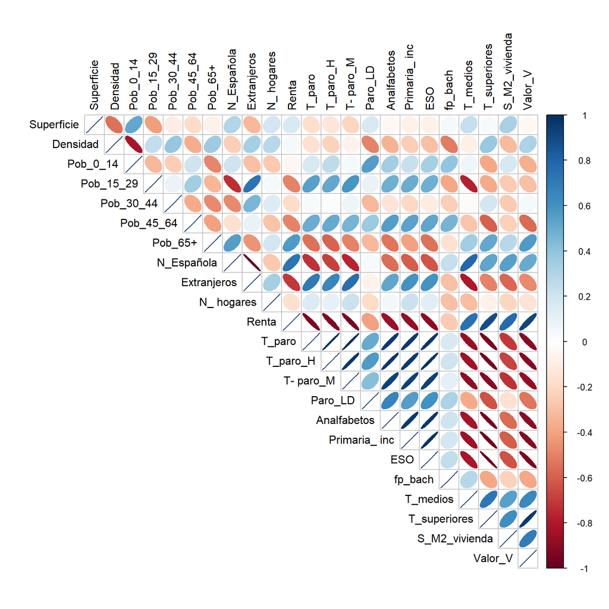

```r
corrplot(cor_mat, type = "upper",
         tl.col = "black",  method = "ellipse")
```

```r
# PREGUNTAS:
# 1) ¿cuáles son las variables más correlacionadas (linealmente)?
# 2) ¿Cómo es el sentido de esa correlación?

# 1) Por un lado, tenemos las correlaciones altas obvias, ya estén causadas por
# variables que suman 100%, y que por tanto, si una toma valores elevados, la otra
# necesariamente será menor (por ej, N_Española y Extranjeros tienen una correlación
# muy elevada y negativa, ya que si el porcentaje de Extranjeros es mayor,
# necesariamente el de españoles en menor, y vicecersa).

# O los indicadores de estudios, si hay más gente con estudios superiores,
# necesariamente la tasa con estudios solo de ESO es forzosamente menor.

# O T_paro y las otras tasas de paro, pues lógicamente si el paro es elevado en
# general, cabe esperar que lo sea también cuando miramos solo a hombres o solo a
# mujeres.

# Más allá de esto, observamos las mayores correlaciones entre:
# - Densidad y Pob_0_14 (corr negativa, como si la gente con niños pequeños
#   prefiriese vivir en sitios menos abarrotados)
# - Las tasas de paro están correlacionadas positivamente con los índices de
#   estudios de menor nivel (analfabetos, primaria, ESO), mientras que están
#   negativamente corr con los índices de mayor nivel de estudios (T_superiores)
# - Las tasas de paro y los niveles de estudio más bajos también están
#   correlacionadas negativamente con Valor_V y con renta --> en los barrios
#   con casas más caras y con mayores rentas, vive gente con niveles de estudio
#   más elevados y con menor tasa de paro.
```

# Ejercicio 4

> Haciendo uso de `{ggplot2}`, representa los gráficos de dispersión de las variables T_paro (eje y) con relación a Analfabetos (eje x). Realiza un nuevo gráfico visualizando T_paro en relación a T_superiores. Comentar el sentido de las nubes de puntos, junto con las correlaciones obtenidas anteriormente. Personaliza el gráfico todo lo que puedas.

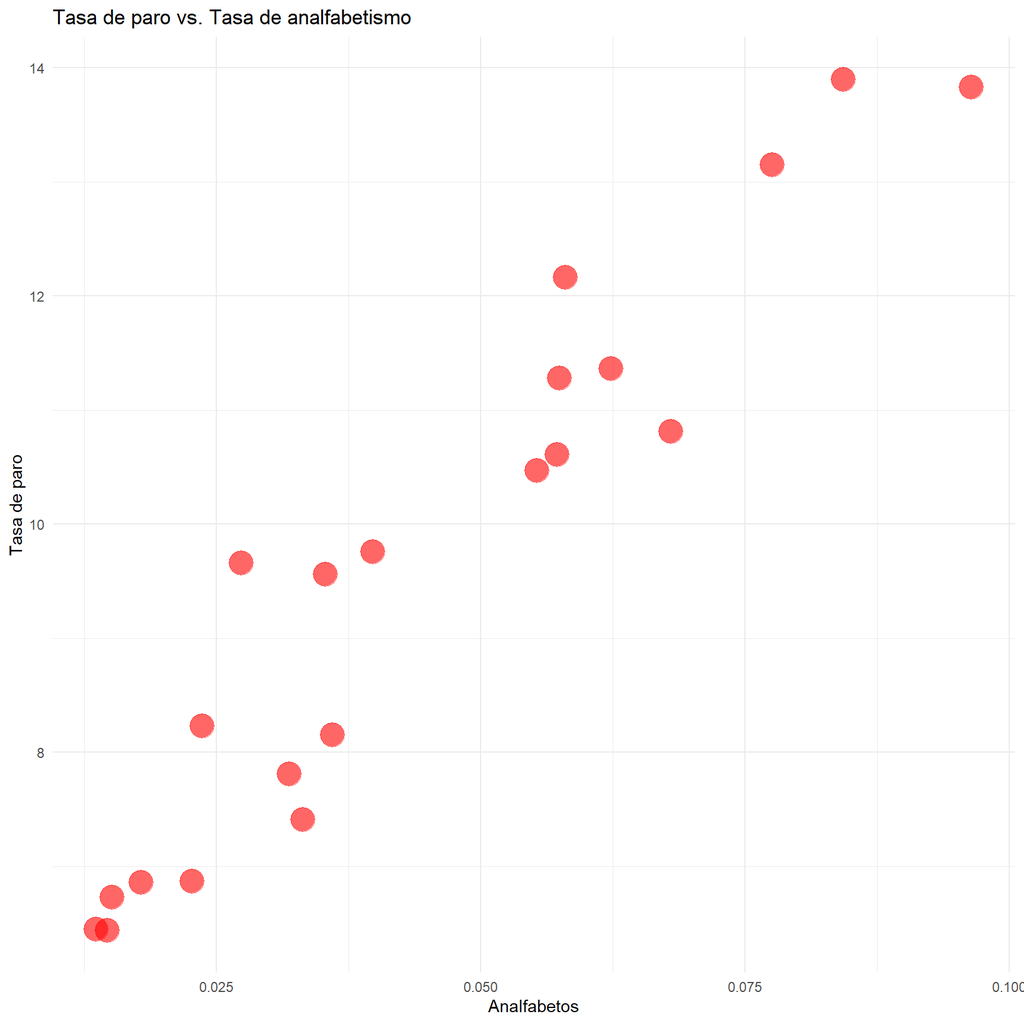

```r
ggplot(distritos, aes(x = Analfabetos, y = T_paro)) +
  geom_point(size = 7, alpha = 0.6, color = 'red') +
  labs(x = 'Analfabetos', y = 'Tasa de paro',
       title = 'Tasa de paro vs. Tasa de analfabetismo') +
  theme_minimal()
```

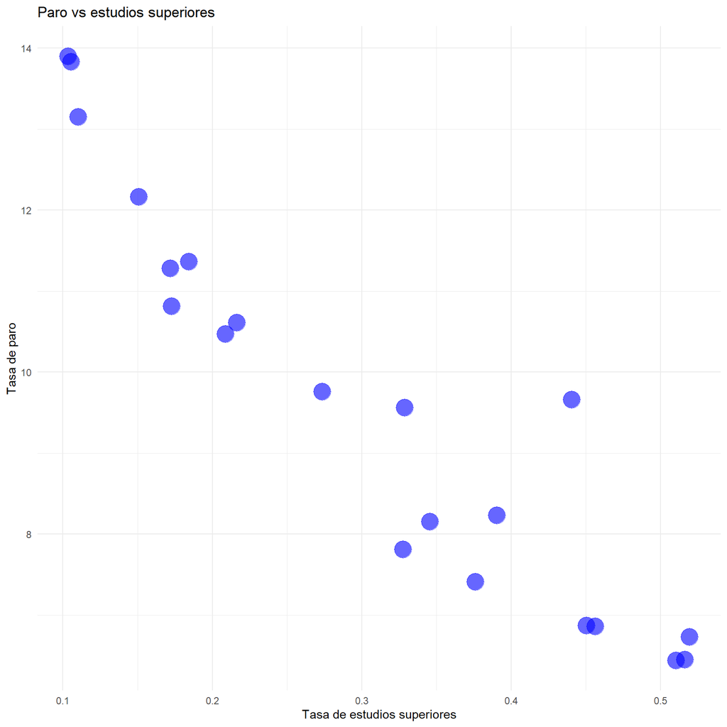

```r
ggplot(distritos, aes(x = T_superiores, y = T_paro)) +
  geom_point(size = 7, alpha = 0.6, color = 'blue') +
  labs(x = 'Tasa de estudios superiores', y = 'Tasa de paro',
       title = 'Paro vs estudios superiores') +
  theme_minimal()
```